# Analysis - Daims Actinobacteria ENR4 assembly

Mads Albertsen

November 24, 2015

## Introduction

This report documents the binning of a Actinobacteria genome from an enrichment reactor (ENR4). See [Daims et al., 2015: Complete Nitrification by Nitrospira Bacteria](https://doi.org/10.1038/nature16461) for further details.

## Load the mmgenome package

In case you haven’t installed the [mmgenome package](http://madsalbertsen.github.io/mmgenome/), see the [Load data example](http://madsalbertsen.github.io/mmgenome/Load_data.html).

```r
library("mmgenome")
```

## Import data

The Rmarkdown file [Load_data.Rmd](http://madsalbertsen.github.io/mmgenome/Load_data_ENR4.html) describes the loading of the data and can be imported using the `mmimport` function. However, the preprocessed data can also be downloaded directly from figshare: [Daims_ENR4](http://dx.doi.org/10.6084/m9.figshare.1613277). Hence, here we import the prepocessed data from figshare instead.

```r
load("Daims_ENR4.RData")
```

## Data overview

The object `d` contains information on scaffolds and essential genes within the scaffolds. For each scaffold the dataset contains the following information: The columns `ENR4A`, `ENR4E`, `ENR4F` and `ENR6` contain the coverage information from 4 different samples; `PC1`, `PC2` and `PC3` contain coordinates of the three first principal components from a PCA analysis on tetranucleotide frequencies; `essential` contain information taxonomic information for each scaffold based on classification on essential genes; `rRNA` contain taxonomic information on scaffolds that have an associated 16S rRNA gene.

```r
colnames(d$scaffolds)
```

```
##  [1] "scaffold"  "length"    "gc"        "ENR4A"     "ENR4E"
##  [6] "ENR4F"     "ENR6"      "PC1"       "PC2"       "PC3"
## [11] "essential" "rRNA16S"
```

The basic statistics of the full dataset can be summarised using the `mmstats` function.

```r
mmstats(d, ncov = 4)
```

```
##                General Stats
## n.scaffolds           161.00
## GC.mean                65.60
## N50                198700.00
## Length.total     12846008.00
## Length.max        1306334.00
## Length.mean         79788.90
## Coverage.ENR4A        157.66
## Coverage.ENR4E        139.64
## Coverage.ENR4F        255.62
## Coverage.ENR6         150.12
## Ess.total             419.00
## Ess.unique            107.00
```

## Extract the Actinobacteria

The combination of the coverage of sample `ENR4A` and `ENR4E` provides the cleanest separation of the genomes and are used for binning. A subspace is defined that clearly seperates the Actinobacteria from the three other species.

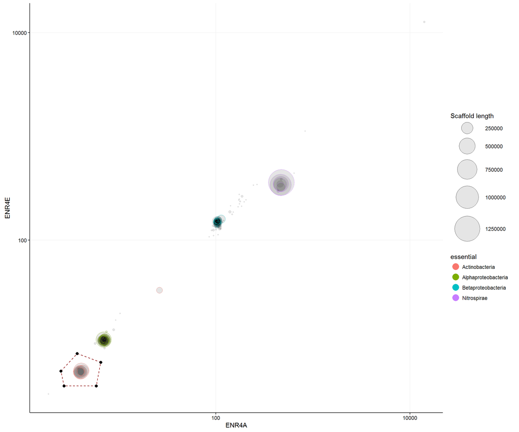

```r
p <- mmplot(data = d, x = "ENR4A", y = "ENR4E", log.x = T, log.y = T, color = "essential")

#p
#sel <- mmplot_locator(p)

sel <- data.frame(ENR4A  =  c(2.54, 3.72, 6.53, 5.86, 2.73),
                  ENR4E  =  c(5.45, 8.06, 6.63, 3.93, 3.93))

mmplot_selection(p, sel)
```

```r
dA <- mmextract(d, sel)
```

```r
mmstats(dA, ncov = 4)
```

```
##                General Stats
## n.scaffolds             9.00
## GC.mean                70.10
## N50                339735.00
## Length.total      2103759.00
## Length.max         469456.00
## Length.mean        233751.00
## Coverage.ENR4A          4.06
## Coverage.ENR4E          5.39
## Coverage.ENR4F          9.99
## Coverage.ENR6           0.00
## Ess.total              91.00
## Ess.unique             91.00
```

## Using paried-end connections

Until now we have just used coverage profiles to extract scaffolds related to our genome of interest. However, some scaffolds might be present in many copies (repeats) and hence have a much higher coverage than the rest of the genome. In addition, some scaffolds will by chance have a slightly different coverage profile than the rest of the genome and thereby also been missed.

The function `mmplot_network` can be used to generate a network plot of scaffolds connected by paired-end reads. We start by plotting the scaffolds we have in our current subset.

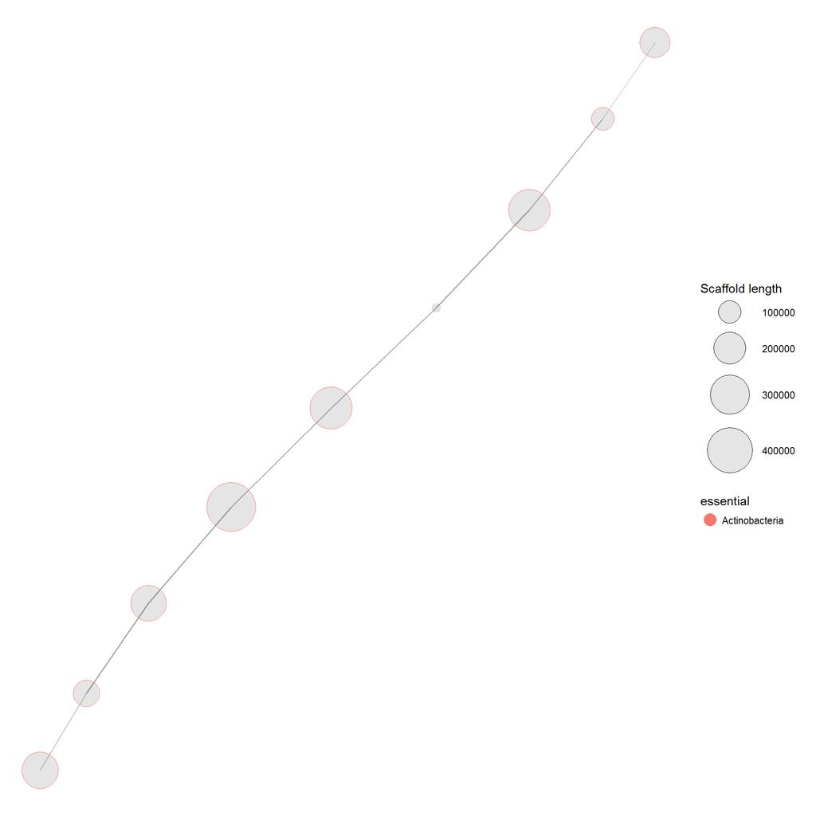

```r
mmplot_network(data = dA, network = pe, nconnections = 2, color = "essential", scale.links = 0.5)
```

All scaffolds seem to be nicely connected and we should be able to improve the assembly substantial in the refinement stage. To include repeats and other missed scaffolds we simply extract all scaffolds that are directly connected by paired-end reads to our current subset dB using mmextract_network. Only scaffolds directly connected to the subset is extracted.

```r
dB <- mmextract_network(subset = dA, original = d, network = pe, nconnections = 5, type = "direct")
```

… and then plot the new subset. It seems like we included a single high coverage scaffold that was missed initially.

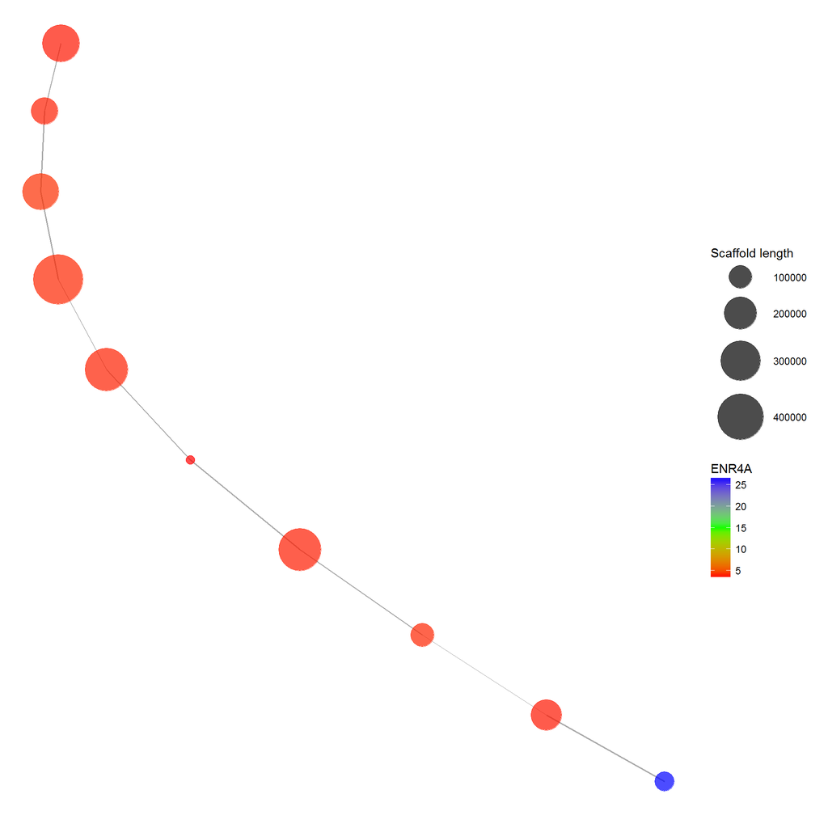

```r
mmplot_network(data = dB, network = pe, nconnections = 1, color = "ENR4A", scale.links = 0.5)
```

```r
mmstats(dB, ncov = 4)
```

```
##                General Stats
## n.scaffolds            10.00
## GC.mean                70.00
## N50                339735.00
## Length.total      2174399.00
## Length.max         469456.00
## Length.mean        217439.90
## Coverage.ENR4A          4.78
## Coverage.ENR4E          6.28
## Coverage.ENR4F         11.79
## Coverage.ENR6           1.55
## Ess.total              99.00
## Ess.unique             99.00
```

## Export the scaffolds

Now that we are happy with the genome bin, the scaffolds can be exported to a separate fasta file using `mmexport`. The genome were then re-assembled using the reads in the genome bin using the SPAdes assembler.

```r
mmexport(data=dB, assembly=assembly, file = "Actinobacteria.fa")
```